# Kaggle DATA Predict in R for ICR, Identifying Age-Related Conditions.

Liu Ya Han

2024-02-20

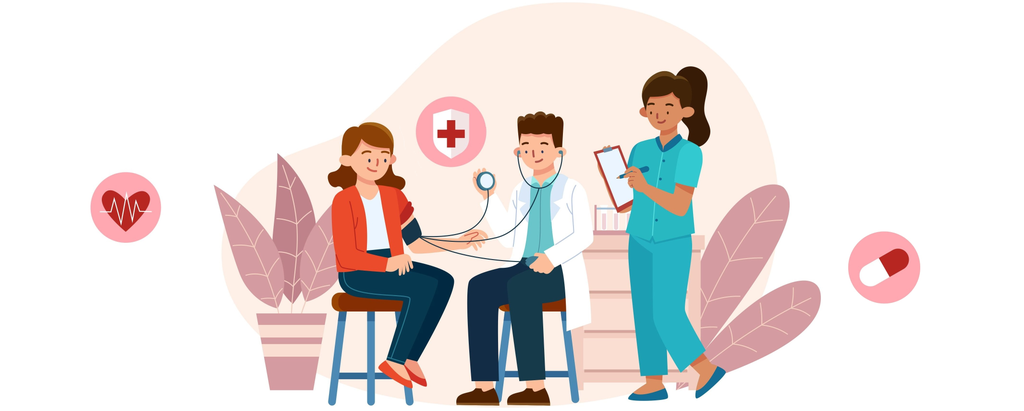

## ICR - Identifying Age-Related Conditions

The ICR Data is come from Kaggle which the actual test set is hidden. It includes about 400 rows in the full test set. The goal is to predict whether a subject has or has not been diagnosed with one of these conditions – a binary classification problem.

https://www.kaggle.com/competitions/icr-identify-age-related-conditions/data

## **DATA**

1. Id : Unique identifier for each observation.
2. AB-GL : Fifty-six anonymized health characteristics. All are numeric except for EJ, which is categorical.
3. Class : 1 indicates the subject has been diagnosed with one of the three conditions, 0 indicates they have not.
4. Alpha : Identifies the type of age-related condition, if present.  
   A : No age-related condition. Corresponds to class 0.  
   B, D, G : The three age-related conditions. Correspond to class 1.

```
##             Id       AB        AF        AH        AM       AR       AX
## 1 000ff2bfdfe9 0.209377 3109.0333  85.20015 22.394407 8.138688 0.699861
## 2 007255e47698 0.145282  978.7642  85.20015 36.968889 8.138688 3.632190
## 3 013f2bd269f5 0.470030 2635.1065  85.20015 32.360553 8.138688 6.732840
## 4 043ac50845d5 0.252107 3819.6518 120.20162 77.112203 8.138688 3.685344
## 5 044fb8a146ec 0.380297 3733.0484  85.20015 14.103738 8.138688 3.942255
## 6 04517a3c90bd 0.209377 2615.8143  85.20015  8.541526 8.138688 4.013127
##         AY        AZ         BC       BD      BN       BP        BQ         BR
## 1 0.025578  9.812214   5.555634 4126.587 22.5984 175.6387 152.70771  823.92824
## 2 0.025578 13.517790   1.229900 5496.928 19.4205 155.8680  14.75472   51.21688
## 3 0.025578 12.824570   1.229900 5135.780 26.4825 128.9885 219.32016  482.14159
## 4 0.025578 11.053708   1.229900 4169.677 23.6577 237.2823  11.05041  661.51864
## 5 0.054810  3.396778 102.151980 5728.734 24.0108 324.5463 149.71716 6074.85948
## 6 0.025578 12.547282   1.229900 5237.541 10.2399 148.4879  16.52612  642.32516
##         BZ       CB        CC       CD        CF       CH       CL       CR
```

[output cut: 41 more lines]

- 變數結構

```r
summary(data)
```

```
##       Id                  AB                AF                AH
##  Length:617         Min.   :0.08119   Min.   :  192.6   Min.   :  85.2
##  Class :character   1st Qu.:0.25211   1st Qu.: 2197.3   1st Qu.:  85.2
##  Mode  :character   Median :0.35466   Median : 3120.3   Median :  85.2
##                     Mean   :0.47715   Mean   : 3502.0   Mean   : 118.6
##                     3rd Qu.:0.55976   3rd Qu.: 4361.6   3rd Qu.: 113.7
##                     Max.   :6.16167   Max.   :28688.2   Max.   :1910.1
##
##        AM                AR                AX                AY
##  Min.   :  3.178   Min.   :  8.139   Min.   : 0.6999   Min.   : 0.02558
##  1st Qu.: 12.270   1st Qu.:  8.139   1st Qu.: 4.1283   1st Qu.: 0.02558
##  Median : 20.533   Median :  8.139   Median : 5.0319   Median : 0.02558
##  Mean   : 38.969   Mean   : 10.128   Mean   : 5.5456   Mean   : 0.06032
##  3rd Qu.: 39.140   3rd Qu.:  8.139   3rd Qu.: 6.4316   3rd Qu.: 0.03684
##  Max.   :630.518   Max.   :178.944   Max.   :38.2709   Max.   :10.31585
##
##        AZ               BC                 BD              BN
##  Min.   : 3.397   Min.   :   1.230   Min.   : 1694   Min.   : 9.887
##  1st Qu.: 8.130   1st Qu.:   1.230   1st Qu.: 4156   1st Qu.:19.421
##  Median :10.461   Median :   1.230   Median : 4998   Median :21.186
##  Mean   :10.566   Mean   :   8.053   Mean   : 5350   Mean   :21.419
##  3rd Qu.:12.970   3rd Qu.:   5.081   3rd Qu.: 6036   3rd Qu.:23.658
##  Max.   :38.972   Max.   :1463.693   Max.   :53061   Max.   :29.307
##
##        BP                BQ                BR                  BZ
##  Min.   :  72.95   Min.   :  1.331   Min.   :    51.22   Min.   :  257.4
##  1st Qu.: 156.85   1st Qu.: 27.834   1st Qu.:   424.99   1st Qu.:  257.4
##  Median : 193.91   Median : 61.642   Median :   627.42   Median :  257.4
##  Mean   : 231.32   Mean   : 98.329   Mean   :  1218.13   Mean   :  550.6
##  3rd Qu.: 247.80   3rd Qu.:134.009   3rd Qu.:   975.65   3rd Qu.:  257.4
##  Max.   :2447.81   Max.   :344.644   Max.   :179250.25   Max.   :50092.5
##                    NA's   :60
##        CB                CC               CD               CF
##  Min.   :  12.50   Min.   :0.1769   Min.   : 23.39   Min.   :  0.5109
##  1st Qu.:  23.32   1st Qu.:0.5637   1st Qu.: 64.72   1st Qu.:  5.0663
##  Median :  42.55   Median :0.6587   Median : 79.82   Median :  9.1230
##  Mean   :  77.10   Mean   :0.6888   Mean   : 90.25   Mean   : 11.2411
##  3rd Qu.:  77.31   3rd Qu.:0.7722   3rd Qu.: 99.81   3rd Qu.: 13.5659
##  Max.   :2271.44   Max.   :4.1030   Max.   :633.53   Max.   :200.9675
##  NA's   :2         NA's   :3
```

[output cut: 65 more lines]

```
##  Min.   :  72.61   Min.   :    13.04   Min.   : 9.433   Min.   :  0.8976
##  1st Qu.:  72.61   1st Qu.:  2798.99   1st Qu.:25.035   1st Qu.: 23.0117
##  Median :  72.61   Median :  7838.27   Median :30.609   Median : 41.0080
##  Mean   : 131.72   Mean   : 14679.60   Mean   :31.490   Mean   : 50.5844
##  3rd Qu.: 127.59   3rd Qu.: 19035.71   3rd Qu.:36.864   3rd Qu.: 67.9317
##  Max.   :1497.35   Max.   :143790.07   Max.   :81.211   Max.   :191.1948
##
##        GL                Class          Alpha
##  Min.   : 0.001129   Min.   :0.000   Length:617
##  1st Qu.: 0.124392   1st Qu.:0.000   Class :character
##  Median : 0.337827   Median :0.000   Mode  :character
##  Mean   : 8.530961   Mean   :0.175
##  3rd Qu.:21.978000   3rd Qu.:0.000
##  Max.   :21.978000   Max.   :1.000
##  NA's   :1
```

- **TABLE** : age-related health conditions
  1. Class : 0, 1.
  2. Alpha : A, Corresponds to class 0. B, D, G, Correspond to class 1.

```r
data_table <- table(data$Class);data_table
```

```
##
##   0   1
## 509 108
```

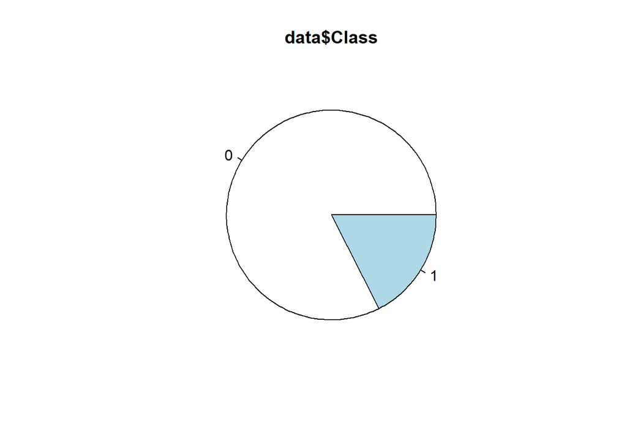

```r
pie(data_table,main = "data$Class")
```

```r
data_table <- table(data$Alpha);data_table
```

```
##
##   A   B   D   G
## 509  61  18  29
```

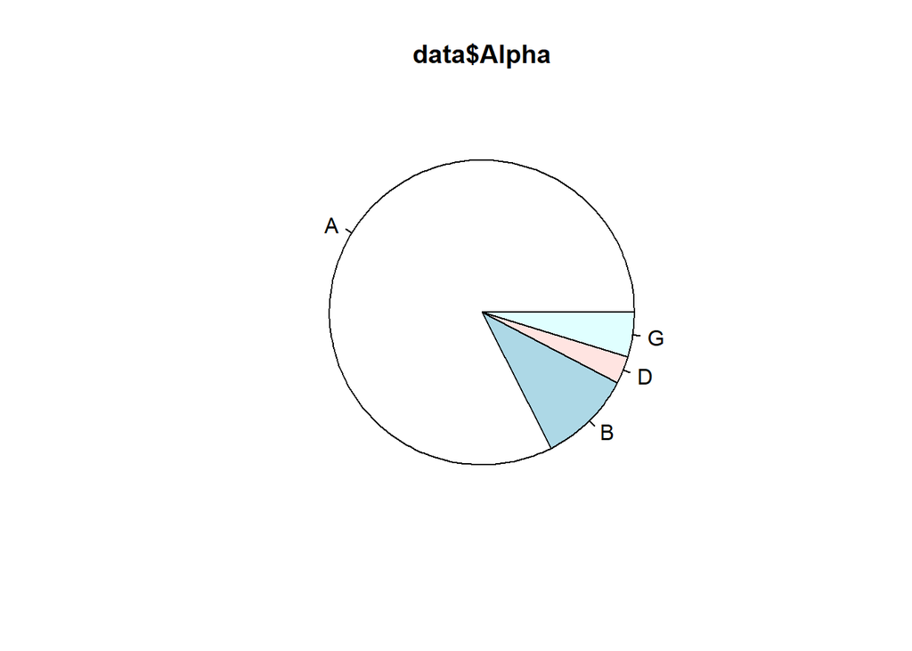

```r
pie(data_table,main = "data$Alpha")
```

## **資料清洗**

> 1. 缺失值處理，例如null & na.  
>    各變數缺失值數量>95% : 可以直接刪除該變數.  
>    各變數缺失值數量<95% : 除了手動檢查原始資料外，還需考慮以哪種方式填補；例如偏態變數以中位數填補，正態以平均數填補或以線性迴歸計算缺失值.
> 2. 重複值處理
> 3. 噪音處理 : 常見方法有分箱法、回歸法與聚類法，藉以找出極端值.
> 4. 特徵挑選
- 缺失資料變數的**直方圖**與**盒鬚圖**

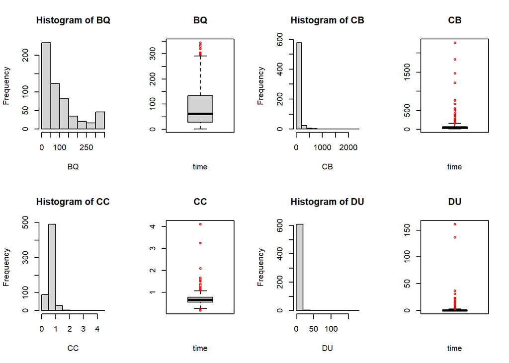

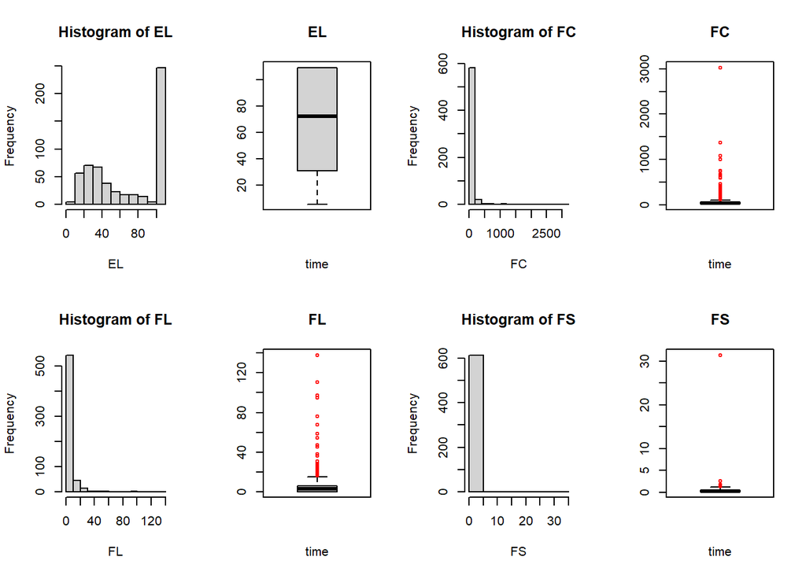

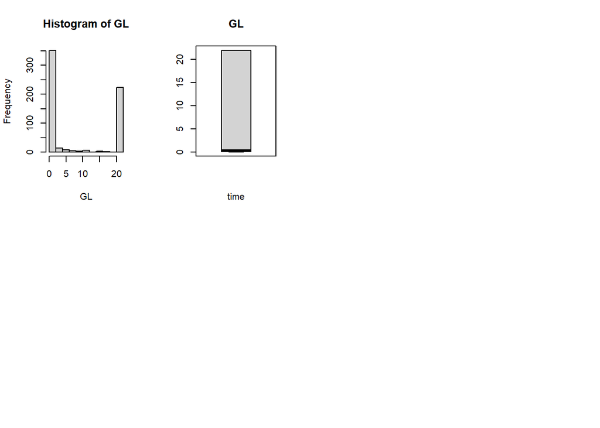

```r
#1資料清洗
#1-1.缺失值處理,例如null.na....
n <- length(which(is.na(data)))+length(which(is.null(data)))
#各變數缺失值數量>95%可以直接刪除該變數.
#各變數缺失值數量<95%需考慮以哪種方式填補,除了手動檢查原始資料外,例如偏態變數以中位數填補,正態以平均數填補或以線性迴歸計算缺失值.
if(n!=0){
  seat <- c() # seat:含缺失值變數位置
  na <- c()  # na:變數缺失值數量>95%變數位置
  for (i in 1:length(data[1,])) {
    if(length(which(is.na(data[,i])))+length(which(is.null(data[,i])))!=0){
      seat <- c(seat,i)
    }
  }
  for (i in seat) {
    if((length(which(is.na(data[,i])))+length(which(is.null(data[,i]))))/length(data[,i])>0.95){
      na <- c(na,i)
    }
  }
  if(is.null(na)=='FALSE'){
    data <- data[ ,-na]}
}

#1-2.1 重複值處理
n <- length(which(duplicated(data)=='TRUE')) #重複值數量
if(n!=0){
  data <- data[!duplicated(data), ]
}

#1-2.2 null.na值處理,直接刪除或以中位數或均值替補.
#方法1.直接刪除
#方法2.偏態以中位數替補
#用直方圖與盒鬚圖辨別辨別分佈型態
par(mfrow=c(2,4))
for(i in 1:length(seat)){
  hist(data[,seat[i]],freq = TRUE,
       main = paste("Histogram of" , colnames(data)[seat[i]]),
       xlab = colnames(data)[seat[i]])
  boxplot(data[,seat[i]],
          main = colnames(data)[seat[i]],
          xlab = "time",outcol="red")
}
```

- **缺失值替代**

[output not shown]

```
## BQ:偏態,以中位數替代, median =  61.64211
```

```
## CB:偏態,以中位數替代, median =  42.55433
```

```
## CC:偏態,以中位數替代, median =  0.6587155
```

```
## DU:偏態,以中位數替代, median =  0.2517405
```

```
## FC:偏態,以中位數替代, median =  36.39401
```

```
## FL:偏態,以中位數替代, median =  3.028141
```

```
## FS:偏態,以中位數替代, median =  0.250601
```

```
## GL:偏態,以中位數替代, median =  0.3378275
```

- **噪音處理** : 刪除單筆資料包含20%以上極端值者.

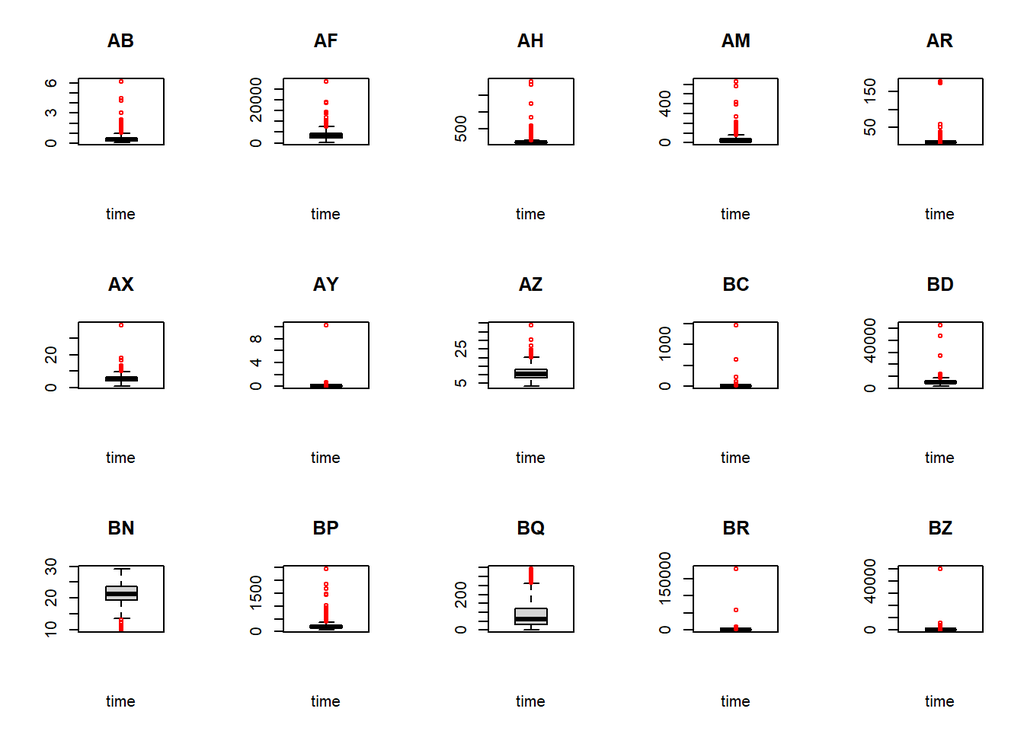

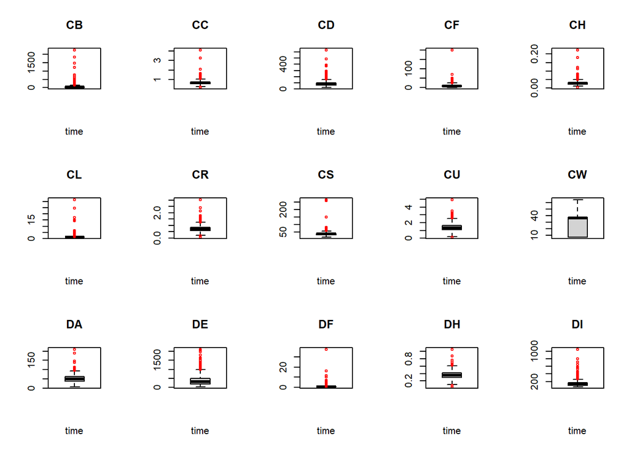

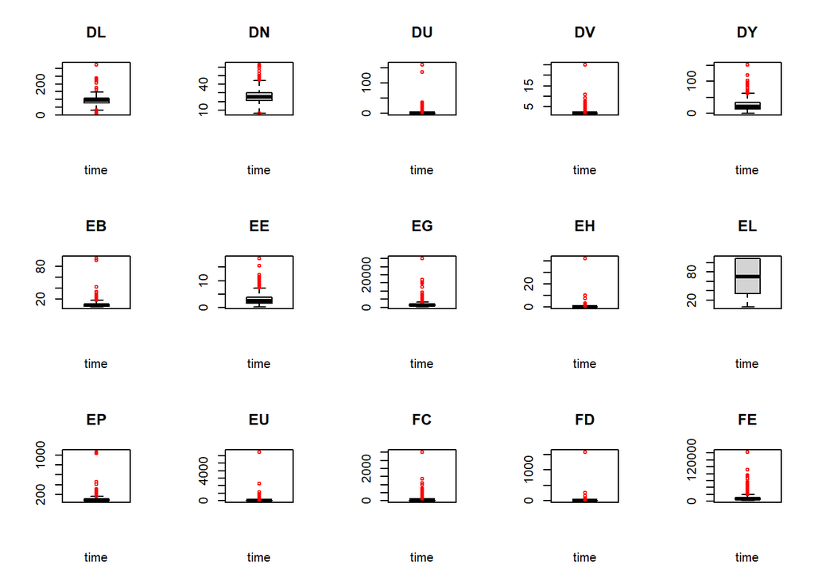

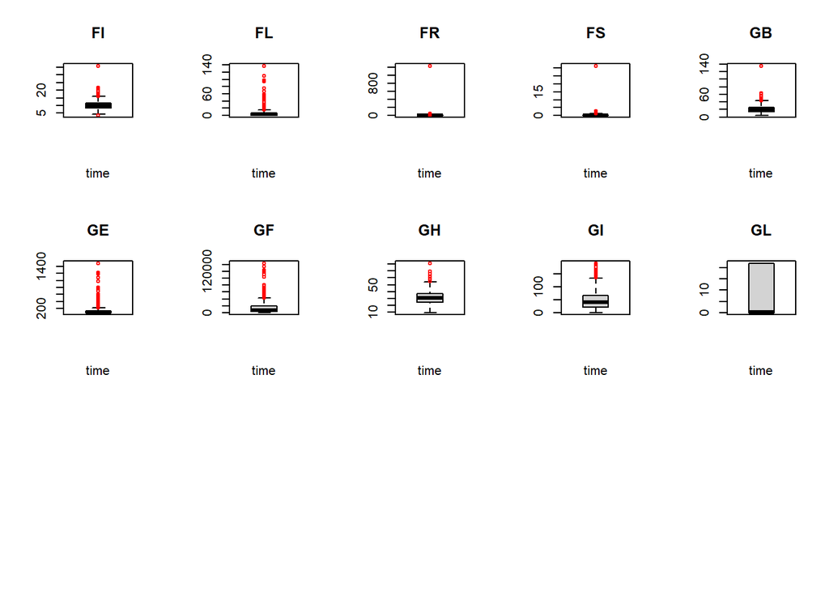

```
## 共刪除 21 筆資料.
```

```r
#盒鬚圖,噪音處理;
par(mfrow=c(3,5))
for(i in c(2:40,42:(length(data)-2))){
  boxplot(data[,i],
          main=colnames(data)[i],
          xlab = "time",outcol="red")
}
```

- **特徵挑選**
  - Correlation : 考慮適度刪除高度相關的變數.
  - 特徵重要程度排序 : caret package

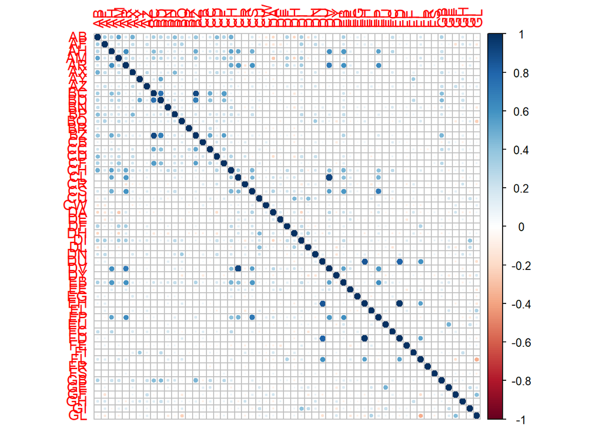

```
##   row col       cor
## 1  FD  EH 0.9713156
## 2  DV  CL 0.9157253
## 3  BZ  BC 0.9092153
## 4  EH  DU 0.8509647
## 5  FD  DU 0.8062627
## 6  BD  BC 0.7593433
## 7  EP  CS 0.7164126
## 8  DV  AR 0.7090023
```

```r
#Correlation : 考慮適度刪除高度相關的變數.
par(mfrow=c(1,1))
correlation <- cor(data[,-c(1,41,58,59)]) #Id與離散型變數
corrplot(correlation)
```

```r
#特徵重要程度排序
# prepare training scheme
control <- trainControl(method="repeatedcv", number=10, repeats=3)
# train the model
model <- train(Alpha~., data=data[,-c(1,41,58)], method="lvq", preProcess="scale", trControl=control)
# estimate variable importance
importance <- varImp(model, scale=FALSE)
# summarize importance
print(importance)
```

```
## ROC curve variable importance
##
##   variables are sorted by maximum importance across the classes
##   only 20 most important variables shown (out of 55)
##
##         A      B      D      G
## DU 0.9343 0.9343 0.9343 0.6530
## CR 0.7914 0.9212 0.6638 0.9212
## FL 0.9031 0.9031 0.9031 0.6347
## AB 0.7837 0.8996 0.7016 0.8996
## GL 0.8798 0.8798 0.8798 0.6275
## EH 0.8427 0.8427 0.8793 0.6867
## DA 0.6683 0.8727 0.6111 0.8727
## BC 0.8725 0.7301 0.8534 0.8725
## FD 0.8203 0.8203 0.8602 0.6919
## FR 0.8378 0.6924 0.7538 0.8378
## AF 0.7118 0.8329 0.6249 0.8329
## DI 0.6341 0.8194 0.5811 0.8194
## DE 0.7531 0.8102 0.6916 0.8102
## FI 0.5598 0.7990 0.5795 0.7990
## DF 0.5642 0.7937 0.5642 0.7937
## EE 0.7584 0.7930 0.7304 0.7930
## BQ 0.7843 0.7047 0.7047 0.7843
## CD 0.7414 0.7818 0.7011 0.7818
## GH 0.7064 0.5520 0.7366 0.7064
## DL 0.5993 0.7346 0.5556 0.7346
```

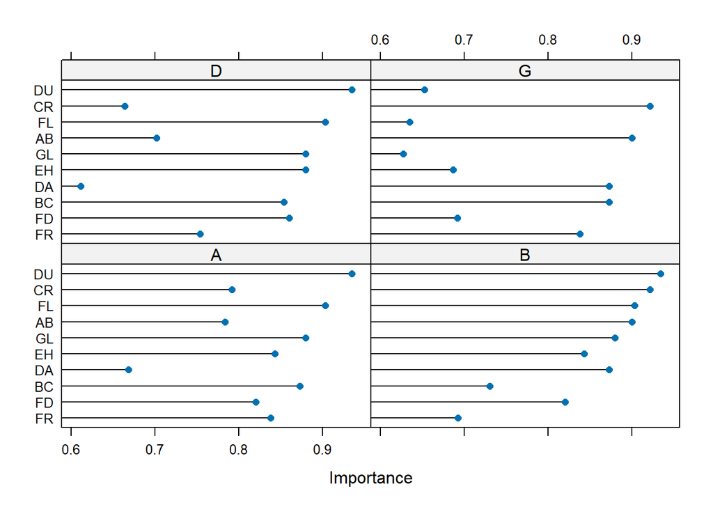

```
## 刪除 BZ CS DV EH FD ,共5個變數.
```

```r
plot(importance,10)
```

```r
data <- data[,-c(16,24,35,40,46)] #BZ,CS,DV,EH,FD
```

## **建模與預測**

> 1. 取7成資料為**train**，其餘為**test**.
> 2. **建模**
> 3. **預測**

#### **建模與預測**

- **多元羅吉斯迴歸(glm)** : ltm package
  - family:  
    1.若y是連續值，設”gaussian”,  
    2.若y是二元分類，設”binomial”,  
    3.若y是多元分類，使用package:VGAM(“vglm”)或nnet(“multinom”).

```
## Call:
## multinom(formula = data_train$Alpha ~ ., data = data_train)
##
## Coefficients:
##   (Intercept)          AB            AF           AH           AM         AR
## B  -0.1509263 -0.05286289 -3.984784e-05 -0.006558726  0.002153208 0.09630950
## D  -0.1774341 -0.06380836  7.177588e-06 -0.007001501  0.007995486 0.12495040
## G   0.1021002  0.42490839 -2.342680e-05  0.011971464 -0.010061900 0.02018948
##            AX          AY          AZ           BC            BD         BN
## B -0.11605973 -0.30520175  0.03238611  0.002643015  3.273055e-05 0.13180853
## D  0.03951675  1.30788374 -0.01658032  0.019419764 -4.503123e-04 0.04353421
## G  0.05490295 -0.06134055 -0.18619806 -0.012539455  1.005106e-04 0.11633918
##              BP           BQ            BR            CB         CC
## B -0.0010812087  0.003484354 -3.739151e-04 -0.0027672077 -0.4082003
## D  0.0022273838  0.006389577 -1.121811e-04 -0.0001344132 -0.8836127
## G  0.0007179518 -0.000190816  3.173996e-05 -0.0036031623 -0.8385099
##             CD           CF            CH         CL          CR         CU
## B  0.003169193  0.008296113 -0.0395547420  0.2647348 -0.06831331 -0.3152782
## D  0.007854072 -0.030298887 -0.0006786629  0.2231666 -0.78789642 -1.1756263
## G -0.002331321  0.083880148 -0.0007554174 -0.4513234 -0.75911773 -0.2595503
##             CW          DA            DE         DF          DH          DI
## B -0.001437563  0.01267926  3.553787e-04 -0.2997375 -0.18902277 0.002718051
## D  0.035021492  0.00211708  8.620886e-05 -2.3820817 -0.09123155 0.001621095
## G  0.006931829 -0.05503352 -1.609599e-03  0.4326768  0.17098995 0.008273105
##              DL          DN         DU           DY          EB           EE
## B -0.0004398532 -0.09295295 0.29896058  0.002957612 0.006876652 -0.173571731
## D  0.0010361573 -0.11674280 0.04133997 -0.004673100 0.095023436 -0.433648791
## G -0.0025769470  0.09077390 0.34293694  0.027435079 0.245666316 -0.003789343
##              EG         EJB            EL          EP            EU
## B -8.135594e-05  0.05189739  0.0055444263 -0.01467658 -0.0005669425
## D  2.356909e-05 -0.25713409 -0.0008464824 -0.01297510  0.0008148422
## G  1.334416e-05  0.33212133  0.0150112430 -0.02511732  0.0014864501
##              FC            FE         FI           FL         FR          FS
## B -0.0001778567  2.282627e-05 -0.1798275  0.007594089 0.01797391 -0.09011913
## D -0.0004515410 -1.064647e-05 -0.1007670  0.068963389 0.01940918 -1.11489407
## G -0.0009704073 -4.055067e-05 -0.1140404 -0.115597639 0.01992038  0.57430461
##            GB            GE            GF          GH           GI          GL
## B  0.02170784 -0.0007889106 -1.152557e-05 -0.01435691  0.001946791 -0.07076732
## D  0.05731336  0.0003047149 -1.768222e-05  0.08943205  0.003119980  0.05614217
## G -0.08151857 -0.0147663588 -3.638359e-04 -0.05750531 -0.001335923  0.12668714
```

[output cut: 26 more lines]

```
##           EJB          EL          EP          EU          FC           FE
## B 0.002084692 0.006477416 0.008407475 0.002866428 0.002624103 1.421014e-05
## D 0.001637421 0.008083691 0.006414451 0.000569322 0.002251986 2.442989e-05
## G 0.001797366 0.011740904 0.008121760 0.002290208 0.002048985 5.009113e-05
##            FI         FL         FR           FS         GB          GE
## B 0.004653873 0.02462051 0.01161679 0.0009891375 0.02529570 0.002662993
## D 0.004735451 0.03076549 0.01161348 0.0004308318 0.02682456 0.001797290
## G 0.006809821 0.03554099 0.01178472 0.0061626713 0.05266481 0.008954139
##             GF         GH          GI         GL
## B 2.026987e-05 0.02593350 0.007282057 0.04104318
## D 1.701728e-05 0.02755057 0.008452051 0.03305564
## G 6.489192e-05 0.04232063 0.013910629 0.04078302
##
## Residual Deviance: 227.0176
## AIC: 539.0176
```

```
##    data_test_y
## pre   A   B   D   G
##   A 130   6   1   5
##   B   6  12   0   0
##   D   6   1   2   1
##   G   8   0   1   0
```

```
## accuracy_mul_glm =  0.9220779
```

- **挑選變數**：根據 AIC 或 BIC指標，越小越好，選取一個表現最佳的模型！
  1. Stepwise:Backward Elimination
  2. Stepwise:Forward Selection
  3. both

```r
summary(backward)
```

```
## Call:
## multinom(formula = data_train$Alpha ~ AF + AZ + BN + BP + BQ +
##     CB + CD + CR + CU + CW + DF + DH + DL + DN + DU + EB + EE +
##     EG + EJ + EP + FE + FL + FR + GE + GH + GI, data = data_train)
##
## Coefficients:
##   (Intercept)            AF         AZ          BN           BP          BQ
## B  -31.452804 -0.0010829100  0.4141326  1.00380517  0.005478383 0.047499930
## D  -36.451935 -0.0009266004  0.7378708 -0.01550763  0.011416847 0.015608568
## G    3.255081  0.0023403568 -0.2435613  1.73438010 -0.007469210 0.006884419
##            CB         CD        CR        CU          CW         DF         DH
## B  0.01104571 0.04923306 -13.69959  1.674493 -0.04118839 -0.6420895   1.898692
## D -0.03482011 0.11034681 -23.64157 -2.940817  0.54750881 -5.8496600  39.668351
## G -0.02718327 0.07670444 -29.69885  4.989313 -0.07670047  2.6285259 -28.390525
##            DL          DN        DU          EB        EE            EG
## B  0.04035556 -0.74083511 1.0810919  0.91363853 -1.300446 -0.0051604095
## D -0.23193384 -0.07867187 0.8138584 -0.01761589 -4.782734 -0.0018266107
## G -0.05373887 -0.37679842 1.1281709  0.47839354 -6.039630 -0.0008223286
##          EJB          EP            FE         FL       FR          GE
## B 24.0509945 -0.17361419  0.0002176354  0.1319665 1.205454 -0.02304689
## D  0.6950821  0.04359718 -0.0001240826 -0.1213791 2.296990  0.02213737
## G -1.6931897 -0.05901653  0.0001456703 -1.1748543 1.113995 -0.06748207
##           GH          GI
## B 0.16333959 -0.01446484
## D 0.46472686  0.10452554
## G 0.07269803 -0.24078644
##
## Std. Errors:
##   (Intercept)           AF         AZ         BN          BP          BQ
## B 0.003033419 0.0002067765 0.10250886 0.10604466 0.003127525 0.005593778
## D 0.001814102 0.0005766500 0.13908324 0.09631166 0.004649273 0.010453270
## G 0.001394301 0.0008964249 0.03594126 0.04231612 0.010433913 0.014872312
##            CB          CD           CR          CU         CW          DF
## B 0.003782845 0.012060344 0.0030747819 0.003814159 0.03276126 0.027786955
## D 0.018301064 0.009974369 0.0031536335 0.004436804 0.07690730 0.002487209
## G 0.014113224 0.029264555 0.0006849825 0.002890971 0.07360102 0.010225388
##             DH         DL         DN         DU         EB          EE
## B 0.0008462099 0.02238033 0.07771916 0.08718988 0.12030271 0.030727859
## D 0.0014691554 0.02686064 0.10602638 0.02984070 0.08588496 0.008289998
## G 0.0007064265 0.05782196 0.03370303 0.00471532 0.03048112 0.002127705
##             EG         EJB         EP           FE         FL         FR
## B 0.0008876063 0.003047294 0.02136469 4.335507e-05 0.03352788 0.07725206
## D 0.0016226893 0.003562378 0.01514142 8.332410e-05 0.05156255 0.07065163
## G 0.0020501798 0.001231634 0.03068324 1.272535e-04 0.01076221 0.01151692
##            GE         GH         GI
## B 0.010481071 0.05333599 0.01355872
## D 0.003285626 0.08323194 0.02565878
## G 0.075670336 0.09472909 0.05197198
##
## Residual Deviance: 73.13537
## AIC: 235.1354
```

```r
pre <- predict(backward,data_test)
cfm <- table(pre,data_test_y);cfm
```

```
##    data_test_y
## pre   A   B   D   G
##   A 131   6   1   3
##   B  11  12   0   0
##   D   7   0   3   0
##   G   1   1   0   3
```

```r
accuracy_backward <- (cfm[1,1]+cfm[2,2])/(cfm[1,1]+cfm[2,2]+cfm[1,2]+cfm[2,1])
cat("accuracy_backward = ",accuracy_backward)
```

```
## accuracy_backward =  0.89375
```

```r
summary(forward)
```

```
## Call:
## multinom(formula = data_train$Alpha ~ DU + DA + FR + CR + DN +
##     BQ + GL + AH + DE + GE + EP + EB + EU + BC + GH + EE, data = data_train)
##
## Coefficients:
##   (Intercept)         DU          DA         FR         CR         DN
## B    4.682964  0.7561841  0.01018583   1.098818  -4.655528 -0.3323161
## D   -9.048361 -2.0350796 -0.04119132   5.036299  -7.356278 -0.2441338
## G   81.448324 -2.0636695 -0.97051550 -12.905063 -44.084635  0.3871043
##           BQ         GL           AH            DE           GE          EP
## B 0.01703131 -0.1500480  0.005022831  0.0009211991 -0.001627710 -0.05950253
## D 0.04950972  0.2842291 -0.003914131 -0.0209829496 -0.009861206 -0.02774722
## G 0.09970033  0.1726239  0.086399276 -0.0944835055 -0.339928054 -0.18319126
##           EB           EU          BC         GH        EE
## B 0.37996872 -0.011063662 -0.01118276 0.03694755 -0.336095
## D 0.01887102 -0.008052917  0.17803962 0.40707536 -1.480014
## G 2.53705482 -0.701742097  0.16916784 0.38050246 -6.597329
##
## Std. Errors:
##   (Intercept)        DU         DA        FR        CR         DN          BQ
## B   2.7436374 0.1462798 0.01744689 0.5583844 2.0329496 0.08588757 0.004801088
## D   0.2976726 1.1095092 0.03234176 1.7545024 3.3205925 0.11860693 0.016497411
## G   0.1700142 1.4638127 0.37145371 0.5702865 0.1978381 0.43829797 0.028673035
##          GL          AH           DE          GE         EP        EB
## B 0.1081546 0.005929525 0.0008624898 0.005564302 0.01986938 0.1195114
## D 0.1386095 0.013878825 0.0090824413 0.007246348 0.01550964 0.1803792
## G 0.2943235 0.036490391 0.0529723405 0.240794691 0.10388635 1.0495497
##            EU         BC         GH        EE
## B 0.009294198 0.05459873 0.03775399 0.1666173
## D 0.010829531 0.11618957 0.14723340 0.6890262
## G 0.163787820 0.11468202 0.55531816 0.7197902
##
## Residual Deviance: 111.5319
## AIC: 213.5319
```

```r
pre <- predict(forward,data_test)
cfm <- table(pre,data_test_y);cfm
```

```
##    data_test_y
## pre   A   B   D   G
##   A 139   9   1   4
##   B   5   9   0   0
##   D   6   1   3   0
##   G   0   0   0   2
```

```r
accuracy_forward <- (cfm[1,1]+cfm[2,2])/(cfm[1,1]+cfm[2,2]+cfm[1,2]+cfm[2,1])
cat("accuracy_forward = ",accuracy_forward)
```

```
## accuracy_forward =  0.9135802
```

```r
summary(both)
```

```
## Call:
## multinom(formula = data_train$Alpha ~ AF + AZ + BD + BN + BQ +
##     CC + CD + CR + DF + DL + DN + DU + EB + EE + EG + EJ + EP +
##     FE + FL + FR + FS + GE + GH + GI + DE + AR + EL, data = data_train)
##
## Coefficients:
##   (Intercept)           AF         AZ          BD         BN         BQ
## B   -52.19231 -0.002738430  1.0517901 0.002717409  1.7758614 0.15131510
## D    10.76356  0.002548216  0.8816125 0.004672917 -1.6521730 0.05760206
## G     4.77426  0.004736048 -1.2745266 0.002432164  0.5756337 0.06821597
##           CC        CD        CR        DF          DL         DN        DU
## B  -3.078254 0.1251337 -40.38782 -6.435579  0.15452383 -1.9819764  2.498541
## D -38.296357 0.2513142 -29.58681 -8.503047 -0.28339661 -0.9480800 -1.083401
## G  -5.415913 0.2065938 -43.27801  4.801040 -0.07398478 -0.5881673 -0.377662
##           EB        EE            EG        EJB          EP            FE
## B  2.8909416  -3.11140 -0.0097629294  33.846157 -0.46142411  0.0005398319
## D -0.4351447 -10.77915  0.0005105633 -10.113623  0.07741537 -0.0002263650
## G  1.4650507 -10.48945  0.0003718619  -3.722985 -0.16776230  0.0002328027
##           FL        FR          FS          GE        GH         GI
## B  0.4288937 0.7852166  -7.9341139 -0.08451908 0.3795574 -0.0983592
## D  0.6218193 0.8717090 -12.5026309  0.02142876 1.4122365  0.1947040
## G -1.8206628 0.4377497   0.2036347 -0.06991261 1.0138528 -0.3671233
##             DE        AR          EL
## B  0.006877204 1.2797536  0.06507861
## D -0.057649649 0.7935923  0.03693092
## G -0.057207956 0.6464357 -0.05644303
##
## Std. Errors:
##    (Intercept)           AF         AZ           BD         BN          BQ
## B 0.0028313560 0.0003589849 0.10496231 0.0004540265 0.11159847 0.006641279
## D 0.0015841326 0.0005351028 0.05870352 0.0008043464 0.02954792 0.016378400
## G 0.0008153339 0.0007635421 0.01043945 0.0007795174 0.02067840 0.042483617
##             CC         CD          CR           DF         DL         DN
## B 0.0020146387 0.02012005 0.004342250 0.0036695285 0.02208428 0.08825811
## D 0.0014754502 0.01740144 0.002186468 0.0011251243 0.04472954 0.07551673
## G 0.0005017136 0.04093165 0.001902048 0.0007820536 0.08359221 0.03185583
##            DU          EB          EE          EG         EJB         EP
## B 0.061761670 0.095643015 0.023268981 0.001114418 0.003107023 0.02743849
## D 0.008042835 0.020444141 0.009356635 0.002394862 0.003588963 0.01761702
## G 0.010027478 0.008841092 0.003698352 0.003705152 0.001686041 0.03728074
##             FE         FL          FR           FS          GE         GH
## B 3.858159e-05 0.04879107 0.007995403 0.0027299254 0.013740710 0.05524666
## D 1.865896e-04 0.06210654 0.005115232 0.0015967098 0.004939822 0.14105402
## G 6.529826e-04 0.01673498 0.003951860 0.0007658799 0.037119399 0.05992543
##           GI          DE         AR         EL
## B 0.01889665 0.001343329 0.05037193 0.01299289
## D 0.03374566 0.006480173 0.01742237 0.05242144
## G 0.11921980 0.024160938 0.01917646 0.10692962
##
## Residual Deviance: 43.45446
## AIC: 211.4545
```

```r
pre <- predict(both,data_test)#predict(both,data_test,"probs")
cfm <- table(pre,data_test_y);cfm
```

```
##    data_test_y
## pre   A   B   D   G
##   A 135   7   1   2
##   B   9  12   1   0
##   D   5   0   0   1
##   G   1   0   2   3
```

```r
accuracy_both <- (cfm[1,1]+cfm[2,2])/(cfm[1,1]+cfm[2,2]+cfm[1,2]+cfm[2,1])
cat("accuracy_both = ",accuracy_both)
```

```
## accuracy_both =  0.9018405
```

- **SVM**：e1071 package
  - Support Vector Machine，支持向量機。
  - 在高維或無限維空間中找到能最完美（max.margin）分類的超平面或超平面集合，無論資料是線性可分或線性不可分皆適用。但須注意在特徵遠大於樣本的情況下容易有過擬和問題。
  - 針對小樣本、非線性、高維度與局部最小點等問題具有相對的優勢。

```r
tune <- tune.svm(data_train$Alpha ~ data_train$AB+data_train$AF+data_train$AH+
                   data_train$AM+data_train$AR+data_train$AX+data_train$AY+data_train$AZ+
                   data_train$BC+data_train$BD+data_train$BN+data_train$BP+data_train$BQ+
                   data_train$BR+data_train$CB+data_train$CC+data_train$CD+
                   data_train$CF+data_train$CH+data_train$CL+data_train$CR+
                   data_train$CU+data_train$CW+data_train$DA+data_train$DE+data_train$DF+
                   data_train$DH+data_train$DI+data_train$DL+data_train$DN+data_train$DU+
                   data_train$DY+data_train$EB+data_train$EE+data_train$EG+
                   data_train$EJ+data_train$EL+data_train$EP+data_train$EU+
                   data_train$FC+data_train$FE+data_train$FI+data_train$FL+
                   data_train$FR+data_train$FS+data_train$GB+data_train$GE+data_train$GF+
                   data_train$GH+data_train$GI+data_train$GL,data=data_train,
                 type="C-classification",kernel="radial",
                 range=list(gamma=2^(-1:1),cost=2^c(-8,-4,-2,0),
                            epsilon=seq(0,10,0.1)))#調整參數cost,epsilon,gamma

svm <- svm(data_train$Alpha ~ .,data=data_train,cost = tune$best.model$cost,
           gamma = tune$best.model$gamma,epsilon = tune$best.model$epsilon,probability=TRUE)
summary(svm)
```

```
##
## Call:
## svm(formula = data_train$Alpha ~ ., data = data_train, cost = tune$best.model$cost,
##     gamma = tune$best.model$gamma, epsilon = tune$best.model$epsilon,
##     probability = TRUE)
##
##
## Parameters:
##    SVM-Type:  C-classification
##  SVM-Kernel:  radial
##        cost:  1
##
## Number of Support Vectors:  223
##
##  ( 39 147 14 23 )
##
##
## Number of Classes:  4
##
## Levels:
##  A B D G
```

```r
pre <- predict(svm,data_test)
cfm <- table(pre,data_test_y);cfm
```

```
##    data_test_y
## pre   A   B   D   G
##   A 150  13   4   3
##   B   0   6   0   0
##   D   0   0   0   0
##   G   0   0   0   3
```

```r
accuracy_svm <- (cfm[1,1]+cfm[2,2])/(cfm[1,1]+cfm[2,2]+cfm[1,2]+cfm[2,1])
cat("accuracy_svm = ",accuracy_svm)
```

```
## accuracy_svm =  0.9230769
```

- **集成學習模型架構**

[interactive chart not shown]

> - **Ensemble learning**  
>   使用多個具差異性且精度P>0.5的弱分類器，將其合成一個強分類器。
> - **boosting**  
>   每次訓練使用全部數據進行學習。先建立一弱分類器，將每次訓練錯誤的樣本進行加權，再對所有分類器進行迭代整合。
> - **bagging**  
>   取後放回進行抽樣，得到數個樣本子集，分別對其訓練生成數個分類器，再整合結果。若是回歸問題，使用將預測結果平均得到最終結果；分類問題，依據投票法得到分類結果。
> - **stacking**  
>   先建立多個不同的分類器，再將各個模型的預測值用於訓練下一層分類器。
- **adaboost** : adabag package
  - Adaptive Boosting，自適應增強。
  - 步驟：使用全部數據集學習生成第一個分類器，根據第一個分類器預測結果重新定義數據集。將預測錯誤的樣本提高權重，重複所有步驟。得到n個分類器後，最終以所有分類器綜合投票結果得到Ada Boosting模型的學習成果。
  - 優點：
    - 具有很高的精度（low bias）。
    - 可使用多種不同算法作為弱分類器。
  - 缺點：
    - adaboost的迭代次數（分類器數目，n）設定不易，次數越多精度越高，所需計算時間也就越長。
    - 易受極端值（異常值）影響，可用交叉驗證找到較佳的n值。弱分類器較複雜時，提高迭代次數，測試誤差無明顯差別，及泛化能力沒有增強，有過擬和問題。

```r
#AdaBoost algorithm with different numbers of classifiers
error <- as.numeric()
for(i in 1:100){
  adaboost_fit <- boosting.cv(Alpha ~ .,data=data_train, boos=TRUE, mfinal=i)
  #v:v folds,預設為10
  error[i] <- adaboost_fit$error
}
```

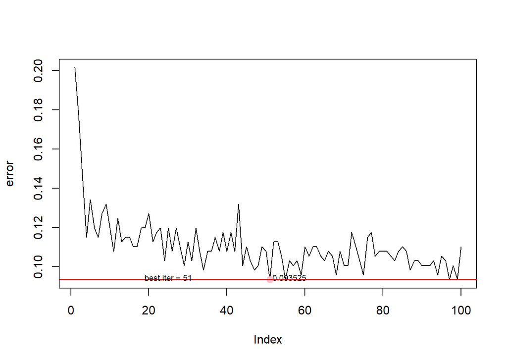

```r
best.iter <- which(error == min(error))[1]

plot(error,type = "l")
points(which(error == min(error))[1],min(error),col = "pink",pch=19,cex=1.2)
text(which(error == min(error))[1]+5,min(error)+0.001,round(min(error),6),cex=0.7)
abline(h=min(error),col="red")
text(20,min(error)+0.001,"best.iter = 51",min(error),cex=0.7)
```

```r
ada.model <- boosting(Alpha ~ .,data=data_train, boos=TRUE, mfinal=best.iter)
# boos(預設:TRUE)每次重新計算權重,反之,每次使用相同權重.
# mfinal:迭代最大次數.

cat("best_mfinal = ",best.iter)
```

```
## best_mfinal =  51
```

```r
ada.predict <- predict(ada.model,data_test)
cfm <- table(ada.predict$class,data_test_y);cfm
```

```
##    data_test_y
##       A   B   D   G
##   A 149   3   2   3
##   B   1  15   1   0
##   D   0   0   1   0
##   G   0   1   0   3
```

```r
accuracy_ada <- (cfm[1,1]+cfm[2,2])/(cfm[1,1]+cfm[2,2]+cfm[1,2]+cfm[2,1])
cat("accuracy_adaboost = ",accuracy_ada)
```

```
## accuracy_adaboost =  0.9761905
```

- **KNN**：class package
  - 步驟：找到距離最近的K個鄰居→進行投票→決定類別。
  - 在資料為連續型變數前提下，以歐式距離作為距離度量。依據測試點周圍的k個樣本（以距離作為判斷準則）的類別出現頻繁次數，推測該樣本類別。
  - 如何選擇一個最佳的K值取決於資料。一般情況下，在分類時較大的K值能夠減小雜訊的影響，但會使類別之間的界限變得模糊；而K值太小，卻又容易受到噪音的影響。經驗法則是盡量讓K值低於樣本數的平方根。實務上，也可透過不斷拆分訓練集與測試集的交叉驗證找到較為穩定的K值。

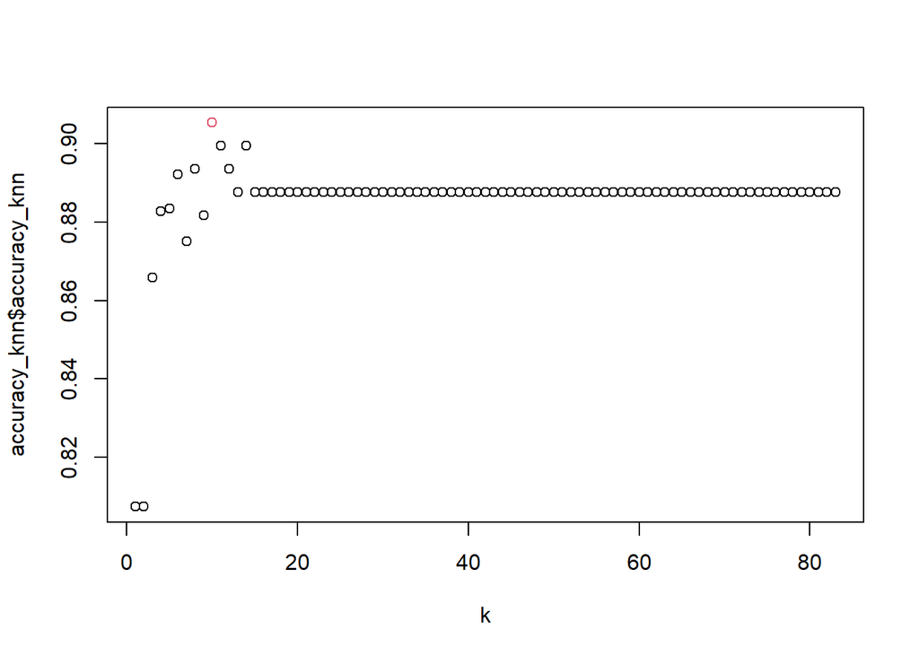

```r
data_train_knn <- data_train[,-36] #chr
data_test_knn <- data_test[,-36] #chr

knn <- knn(data_train_knn[,-51],data_test_knn,data_train_knn[,51],k=7)#k建議設為奇數,通常k的上限為訓練樣本數的20%。
cfm <- table(knn,data_test_y)
accuracy_knn <- (cfm[1,1]+cfm[2,2])/(cfm[1,1]+cfm[2,2]+cfm[1,2]+cfm[2,1])

for (i in 1:round(0.2*nrow(data_train))) {
  knn <- knn(data_train_knn[,-51],data_test_knn[,-51],data_train_knn[,51],k=i)#k建議設為奇數,通常k的上限為訓練樣本數的20%。
  cfm <- table(knn,data_test_y)
  accuracy_knn[i] <- (cfm[1,1]+cfm[2,2])/(cfm[1,1]+cfm[2,2]+cfm[1,2]+cfm[2,1]);accuracy_knn
}
accuracy_knn <- as.data.frame(accuracy_knn)
accuracy_knn$col <- rep("1",nrow(accuracy_knn))
accuracy_knn$col[which.max(accuracy_knn$accuracy_knn)] <- "2"
plot(1:round(0.2*nrow(data_train)),accuracy_knn$accuracy_knn,xlab="k",col=accuracy_knn$col)
```

```r
n <- which.max(accuracy_knn$accuracy)
cat("BEST k = ",n)
```

```
## BEST k =  10
```

```r
knn <- knn(data_train_knn[,-51],data_test_knn[,-51],data_train_knn[,51],k=n)#k建議設為奇數,通常k的上限為訓練樣本數的20%。
cfm <- table(knn,data_test_y);cfm
```

```
##    data_test_y
## knn   A   B   D   G
##   A 150  15   4   5
##   B   0   3   0   1
##   D   0   0   0   0
##   G   0   1   0   0
```

```r
accuracy_knn <- (cfm[1,1]+cfm[2,2])/(cfm[1,1]+cfm[2,2]+cfm[1,2]+cfm[2,1])
cat("accuracy_knn = ",accuracy_knn)
```

```
## accuracy_knn =  0.9107143
```

- **決策樹，CART**：caret package
  - 步驟：在決策樹的每一個節點上採二分法，不斷地往下拓展，直至層數達到設定的最大深度為止。
  - 優點：
    - 簡單且具高解釋性。
    - 計算時間快速。
  - 缺點：
    - 容易有過擬和問題，高方差低偏差。
    - 當類別很多時，樹容易過度複雜。

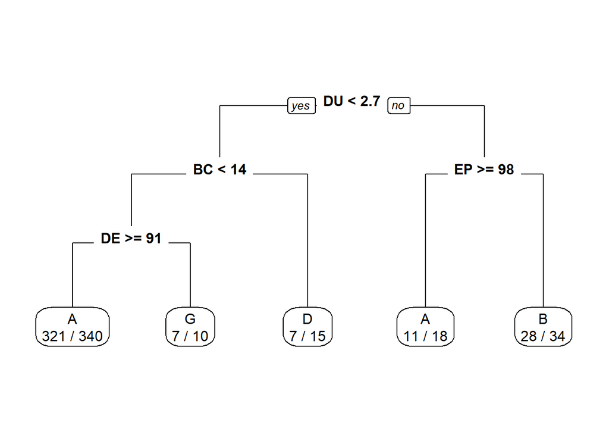

```r
cart.model <- rpart(Alpha ~. ,data=data_train ,method="class")

prp(cart.model,         # 模型
    fallen.leaves=TRUE, # 讓樹枝以垂直方式呈現
    extra=2)# number of correct classifications / number of observations in that node
```

```r
cart.predict <- predict(cart.model,data_test,type="class")
cfm <- table(cart.predict,data_test_y);cfm
```

```
##             data_test_y
## cart.predict   A   B   D   G
##            A 142   5   2   5
##            B   6  12   0   0
##            D   0   1   1   0
##            G   2   1   1   1
```

```r
accuracy_cart <- (cfm[1,1]+cfm[2,2])/(cfm[1,1]+cfm[2,2]+cfm[1,2]+cfm[2,1]);accuracy_cart
```

```
## [1] 0.9333333
```

```r
#k-fold cross-validation:避免overfitting.
#library(caret)
train_control <- trainControl(method="cv", number=10)
train_control.model <- train(Alpha ~., data=data_train, method="rpart", trControl=train_control);train_control.model
```

```
## CART
##
## 417 samples
##  51 predictor
##   4 classes: 'A', 'B', 'D', 'G'
##
## No pre-processing
## Resampling: Cross-Validated (10 fold)
## Summary of sample sizes: 375, 375, 376, 377, 375, 375, ...
## Resampling results across tuning parameters:
##
##   cp          Accuracy   Kappa
##   0.05263158  0.8584393  0.4879569
##   0.06578947  0.8488574  0.4438787
##   0.25000000  0.8178996  0.1237989
##
## Accuracy was used to select the optimal model using the largest value.
## The final value used for the model was cp = 0.05263158.
```

- **GBDT** : gbm package
  - Gradient boosting，梯度提升法。GBDT，迭代的決策樹算法，由多棵子決策樹累加得出預測值。
  - 步驟：最初以常數作為預測值，之後在每次預測時加入新的學習函數。在函數空間進行殘差計算，當殘差>0，繼續進行運算，使其損失函數最小。每次基於上一輪殘差進行迭代，目的為降低模型偏差，提高精度。
  - 優點：
    - 無論離散型或連續型資料皆可，適用於迴歸與分類問題。
    - 充分考慮了每個弱分類器的權重。
    - 因使用了決策樹，可解釋性較強。
  - 缺點：
    - 由於弱分類器的串行依賴，導致難以並行訓練數據。
  - 參數：
    1. distribution:loss function,i.e. “gaussian”(squared error),“laplace” (absolute loss),“bernoulli”(logistic regression for 0-1 outcomes), “huberized”(huberized hinge loss for 0-1 outcomes)等.
    2. n.trees:迭代次數
    3. shrinkage:學習速率,步子邁得太大容易不斷在最小值左右徘徊，因此學習速率越小越好，但步子若太小，步數就得增加，即訓練的迭代次數需加大才能使模型達到最優。如此訓練所需時間和計算資源也相應加大，gbm作者經驗法則是設定參數在0.01-0.001之間。
    4. bag.fraction:再抽樣比率.

```r
gbm <- gbm(data_train$Alpha~.,data_train, distribution = "multinomial",
           n.trees=1000, n.minobsinnode = 10, cv.folds = 5)
best.iter <- gbm.perf(gbm,method="cv")
```

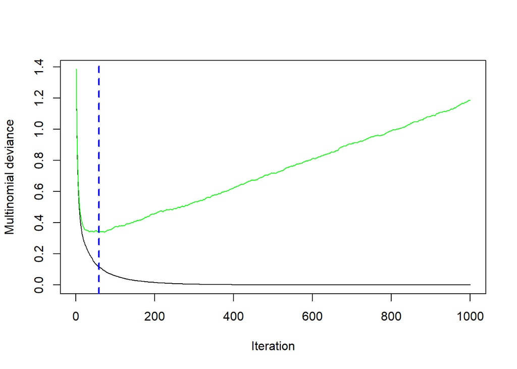

```r
gbm.predict <- predict(gbm,data_test)
```

```
## Using 59 trees...
```

```r
head(gbm.predict)
```

```
## , , 59
##
##               A          B         D         G
## [1,] -0.6552952  2.0506014 -2.816112 -3.320289
## [2,]  1.9154860 -2.3490930 -2.282791 -2.478012
## [3,]  0.8739882 -2.2969251 -2.768669 -3.332144
## [4,]  3.3623642 -2.5459188 -3.638649 -3.277983
## [5,]  2.4832357  0.3145237 -2.820418 -2.036101
## [6,]  2.5207155 -3.3701377 -3.148828 -3.727783
```

```r
prob.gbm.predict <- as.data.frame(apply(gbm.predict, 1, which.max))
colnames(prob.gbm.predict) <- "gbm.predict"

prob.gbm.predict <- prob.gbm.predict %>%
  mutate(gbm.predict = gbm.predict) %>%
  mutate(gbm.predict = gsub("1","A",gbm.predict)) %>%
  mutate(gbm.predict = gsub("2","B",gbm.predict)) %>%
  mutate(gbm.predict = gsub("3","D",gbm.predict)) %>%
  mutate(gbm.predict = gsub("4","G",gbm.predict))

cfm <- table(prob.gbm.predict$gbm.predict,data_test_y);cfm
```

```
##    data_test_y
##       A   B   D   G
##   A 144   4   1   4
##   B   6  13   1   0
##   D   0   1   1   0
##   G   0   1   1   2
```

```r
accuracy_GB <- (cfm[1,1]+cfm[2,2])/(cfm[1,1]+cfm[2,2]+cfm[1,2]+cfm[2,1])
cat("accuracy_GB = ",accuracy_GB)
```

```
## accuracy_GB =  0.9401198
```

- **XGboost** : xgboost package
  - eXtreme Gradient Boosting，極限梯度提升法。
  - 與GBDT方法相似，但對樹的結構加入懲罰項L1(Lasso)與L2(Ridge)進行正則化約束，防止模型過度複雜，降低過擬和發生的可能性。
  - 參數：
    1. data須為matrix,建議使用xgb.DMatrix.
    2. objective[默認reg:linear] ，此參數定義需要被最小化的損失函数。  
       常用參數有： reg:linear：線性迴歸  
       reg:logistic：羅吉斯迴歸  
       binary:logistic：二元分類的羅吉斯迴歸，返回預測的概率  
       binary:logitraw：二元分類的羅吉斯迴歸，返回logit變換前的值  
       multi:softmax：多元分類問題，需要设置num_class（分類的個數）  
       multi:softprob：和softmax一样，但返回的是每個數據各類別的概率。
    3. eval_metric[默認值取于objective參數的取值]，對於有效數據的度量方法。對於迴歸問題而言，默认值是rmse，對於分類問題，默认值是error。  
       典型值有：  
       rmse：均方根誤差  
       mae：平均絕對誤差  
       logloss：負對數似然函數值  
       error：二分類錯誤率(阈值為0.5)  
       merror：多分類錯誤率  
       mlogloss：多分類logloss損失函数  
       auc：曲線下面積

```r
data_train_Matrix <- data_train
data_train_Matrix[,52] <- as.numeric(factor(data_train_Matrix[,52]))-1  #Label encoding,A:0,B:1.D:2,G:3
data_train_Matrix <- xgb.DMatrix(data = as.matrix(data_train_Matrix[,-c(36,52)]), label = data_train_Matrix[,52])
data_test_Matrix <- data_test
data_test_Matrix[,52] <- data_test_y  #Label encoding,A:0,B:1.D:2,G:3
data_test_Matrix <- data_test_Matrix%>%
  mutate(V52 = V52) %>%
  mutate(V52 = gsub("A",0,V52)) %>%
  mutate(V52 = gsub("B",1,V52)) %>%
  mutate(V52 = gsub("D",2,V52)) %>%
  mutate(V52 = gsub("G",3,V52))
data_test_y_Label <- data_test_Matrix[,52]
data_test_Matrix <- xgb.DMatrix(data = as.matrix(data_test_Matrix[,-c(36,52)]), label = data_test_Matrix[,52])
xgb.params = list(colsample_bytree = 0.5,#col的抽樣比例，越高表示每棵樹使用的col越多，會增加每棵小樹的複雜度
  subsample = 0.5,# row的抽樣比例，越高表示每棵樹使用的col越多，會增加每棵小樹的複雜度
  booster = "gbtree",
  max_depth = 2,# 樹的最大深度，越高表示模型可以長得越深，模型複雜度越高
  eta = 0.03,# boosting會增加被分錯的資料權重，而此參數是讓權重不會增加的那麼快，因此越大會讓模型愈保守
  eval_metric = "merror",
  objective = "multi:softmax",
  num_class = 4,
  gamma = 0# 越大，模型會越保守，相對的模型複雜度比較低
  )
cv.model <- xgb.cv(params=xgb.params,data=data_train_Matrix,
                  nfold = 5,#5-fold cv
                  nrounds = 200,#測試1-100,各個樹總數下的模型;
                  #如果當nrounds<30時,就已經有overfitting情況發生,那表示不用繼續tune下去了,可以提早停止
                  early_stopping_rounds = 30,
                  print_every_n = 20)#每20個單位才顯示一次結果
```

[output not shown]

```r
xgb <- xgb.train(params=xgb.params,
               data_train_Matrix,
               nrounds = cv.model$best_iteration)
xgb.predict <- gsub(3,"G",gsub(2,"D",gsub(1,"B",gsub(0,"A",predict(xgb,data_test_Matrix)))))
cfm <- table(xgb.predict,data_test_y);cfm
```

```
##            data_test_y
## xgb.predict   A   B   D   G
##           A 150  12   3   6
##           B   0   7   1   0
```

```r
accuracy_XGB <- (cfm[1,1]+cfm[2,2])/(cfm[1,1]+cfm[2,2]+cfm[1,2]+cfm[2,1]);accuracy_XGB
```

```
## [1] 0.9289941
```

```r
cat("accuracy_XGB = ",accuracy_XGB)
```

```
## accuracy_XGB =  0.9289941
```

- **bagging** : ipred package
  - 步驟：從訓練資料中隨機抽取樣本，訓練一個分類器，將樣本放回（n<N）。重複步驟多次，每次抽取相同n的樣本數，產生多個分類器。每個分類器的權重一致，最後將之組合得到最終結果。
  - 將多個高方差或高偏差的弱分類器聚集成一個強分類器，藉此降低方差（variance）或減少偏差（bias）。
  - 若訓練資料中有噪音，透過bagging有機會減少噪音資料被抽取，降低模型不穩定性。

```r
bag.model <- bagging(Alpha ~. ,data=data_train ,
                     coob = TRUE) # Use the OOB sample to estimate the test error
bag.predict <- predict(bag.model,data_test)
cfm <- table(bag.predict,data_test_y);cfm
```

```
##            data_test_y
## bag.predict   A   B   D   G
##           A 140   3   2   5
##           B  10  15   1   0
##           D   0   0   0   0
##           G   0   1   1   1
```

```r
accuracy_bag <- (cfm[1,1]+cfm[2,2])/(cfm[1,1]+cfm[2,2]+cfm[1,2]+cfm[2,1]);accuracy_bag
```

```
## [1] 0.922619
```

```r
cat("accuracy_bagging = ",accuracy_bag)
```

```
## accuracy_bagging =  0.922619
```

- **randon forest** : randomForest package
  - 步驟：隨機抽取部分樣本與部分特徵建立一棵樹，重複步驟得到多棵樹的分類器，最後將之組合得到最終結果。
  - 決策樹的改進模型，除了可提高準確率，同時改進決策樹容易出現過擬和的問題。

```r
randomForest.model <- randomForest(Alpha ~ .,data=data_train)
randomForest.predict <- predict(randomForest.model,data_test)
cfm <- table(randomForest.predict,data_test_y);cfm
```

```
##                     data_test_y
## randomForest.predict   A   B   D   G
##                    A 150   8   2   4
##                    B   0  11   1   0
##                    D   0   0   0   0
##                    G   0   0   1   2
```

```r
accuracy_randomForest <- (cfm[1,1]+cfm[2,2])/(cfm[1,1]+cfm[2,2]+cfm[1,2]+cfm[2,1]);accuracy_randomForest
```

```
## [1] 0.9526627
```

```r
cat("accuracy_randomForest = ",accuracy_randomForest)
```

```
## accuracy_randomForest =  0.9526627
```